# Section 1

### In this section, we will first be evaluating the two provided models in pytorch and keras. Then, we will be creating the provided pytorch model in keras, and vice versa, to compare their performances and results in the two frameworks.

## Provided keras model (labkeras2.ipynb) without GPU

### The first step is to import libraries and create functions that are needed.

```python
import numpy as np
from sklearn.metrics import confusion_matrix
import itertools
import matplotlib.pyplot as plt

def plot_confusion_matrix(cm, classes,
                          normalize=False,
                          title='Confusion matrix',
                          cmap=plt.cm.Blues):
    """
    This function prints and plots the confusion matrix.
    Normalization can be applied by setting `normalize=True`.
    """
    if normalize:
        cm = cm.astype('float') / cm.sum(axis=1)[:, np.newaxis]
        print("Normalized confusion matrix")
    else:
        print('Confusion matrix, without normalization')

    #print(cm)

    plt.imshow(cm, interpolation='nearest', cmap=cmap)
    plt.title(title)
    plt.colorbar()
    tick_marks = np.arange(len(classes))
    plt.xticks(tick_marks, classes, rotation=45)
    plt.yticks(tick_marks, classes)

    fmt = '.2f' if normalize else 'd'
    thresh = cm.max() / 2.
    for i, j in itertools.product(range(cm.shape[0]), range(cm.shape[1])):
        plt.text(j, i, format(cm[i, j], fmt),
                 horizontalalignment="center",
                 color="white" if cm[i, j] > thresh else "black")

    plt.ylabel('True label')
    plt.xlabel('Predicted label')
    plt.tight_layout()
```

### Next, the hyperparameters for the model is set. Then, the model is trained and tested.

```python
from __future__ import print_function
import keras
from keras.datasets import mnist
from keras.models import Sequential
from keras.layers import Dense, Dropout, Flatten
from keras.layers import Conv2D, MaxPooling2D
from keras import backend as K
import time
from datetime import datetime

start_time = datetime.now()

batch_size = 128
num_classes = 10
epochs = 12

# input image dimensions
img_rows, img_cols = 28, 28

# the data, split between train and test sets
(x_train, y_train), (x_test, y_test) = mnist.load_data()

if K.image_data_format() == 'channels_first':
    x_train = x_train.reshape(x_train.shape[0], 1, img_rows, img_cols)
    x_test = x_test.reshape(x_test.shape[0], 1, img_rows, img_cols)
    input_shape = (1, img_rows, img_cols)
else:
    x_train = x_train.reshape(x_train.shape[0], img_rows, img_cols, 1)
    x_test = x_test.reshape(x_test.shape[0], img_rows, img_cols, 1)
    input_shape = (img_rows, img_cols, 1)

x_train = x_train.astype('float32')
x_test = x_test.astype('float32')
x_train /= 255
x_test /= 255
print('x_train shape:', x_train.shape)
print(x_train.shape[0], 'train samples')
print(x_test.shape[0], 'test samples')

# convert class vectors to binary class matrices
y_train = keras.utils.to_categorical(y_train, num_classes)
y_test = keras.utils.to_categorical(y_test, num_classes)

model = Sequential()
model.add(Conv2D(32, kernel_size=(3, 3),
                 activation='relu',
                 input_shape=input_shape))
model.add(Conv2D(64, (3, 3), activation='relu'))
model.add(MaxPooling2D(pool_size=(2, 2)))
model.add(Dropout(0.25))
model.add(Flatten())
model.add(Dense(128, activation='relu'))
model.add(Dropout(0.5))
model.add(Dense(num_classes, activation='softmax'))

model.compile(loss=keras.losses.categorical_crossentropy,
              optimizer=keras.optimizers.Adadelta(),
              metrics=['accuracy'])

history = model.fit(x_train, y_train,
          batch_size=batch_size,
          epochs=epochs,
          verbose=1,
          validation_data=(x_test, y_test))
score = model.evaluate(x_test, y_test, verbose=1)
print('Test loss:', score[0])
print('Test accuracy:', score[1])

print("Time Elapsed: {} seconds".format((datetime.now() - start_time).total_seconds()))
```

```
Downloading data from https://storage.googleapis.com/tensorflow/tf-keras-datasets/mnist.npz
x_train shape: (60000, 28, 28, 1)
60000 train samples
10000 test samples
Test loss: 0.7166295647621155
Test accuracy: 0.8288000226020813
Time Elapsed: 1715.653636 seconds
```

```
dict_keys(['loss', 'accuracy', 'val_loss', 'val_accuracy'])
```

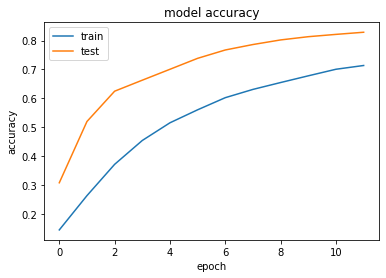

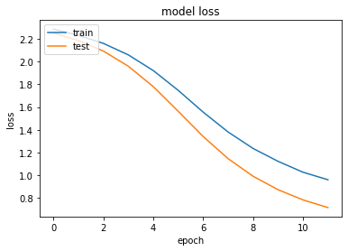

```python
# list all data in history
print(history.history.keys())
# summarize history for accuracy
plt.plot(history.history['accuracy'])
plt.plot(history.history['val_accuracy'])
plt.title('model accuracy')
plt.ylabel('accuracy')
plt.xlabel('epoch')
plt.legend(['train', 'test'], loc='upper left')
plt.show()
# summarize history for loss
plt.plot(history.history['loss'])
plt.plot(history.history['val_loss'])
plt.title('model loss')
plt.ylabel('loss')
plt.xlabel('epoch')
plt.legend(['train', 'test'], loc='upper left')
plt.show()
```

```python
predictions = model.predict(x_test, verbose=0)
```

```python
yitest = np.argmax(y_test, axis=1)

yptest = np.argmax(predictions, axis=1)
print (yitest)
print (yptest)
```

```
[7 2 1 ... 4 5 6]
[7 2 1 ... 4 8 6]
```

```python
cfm = confusion_matrix(yitest, yptest)
print (cfm)
```

```
[[ 932    0    1    3    0    3   20    1   20    0]
 [   0 1086   12   10    1    0    4    0   21    1]
 [  19   25  856   20   11    0   45   25   28    3]
 [   4   14   30  881    0   11    8   28   23   11]
 [   2    7    2    0  771    0   29    6   13  152]
 [  41   32    5  162   33  525   29    5   49   11]
 [  30   20   30    0   12   14  844    1    7    0]
 [   2   42   29    3   17    0    1  884    5   45]
 [  23   47   12   86   14   14   19   23  698   38]
 [  15   22    9   13   72    6    1   51    9  811]]
```

```
Confusion matrix, without normalization
```

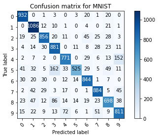

```python
plot_confusion_matrix(cfm, classes=range(10),
                      title='Confusion matrix for MNIST')
```

### Looking at the confusion matrix above, we can see that the model is satisfactory as most of the predictions are right. Significant errors came from predicting digit 5 as 3 and digit 4 as 9. Next, we will try to run this keras model with GPU.

## Provided keras model (labkeras2.ipynb) with GPU

### In this step, we will try to run the program with GPU and see the differences that may happen.

```python
from __future__ import print_function
import keras
from keras.datasets import mnist
from keras.models import Sequential
from keras.layers import Dense, Dropout, Flatten
from keras.layers import Conv2D, MaxPooling2D
from keras import backend as K
import time
from datetime import datetime

start_time = datetime.now()

batch_size = 128
num_classes = 10
epochs = 12

# input image dimensions
img_rows, img_cols = 28, 28

# the data, split between train and test sets
(x_train, y_train), (x_test, y_test) = mnist.load_data()

if K.image_data_format() == 'channels_first':
    x_train = x_train.reshape(x_train.shape[0], 1, img_rows, img_cols)
    x_test = x_test.reshape(x_test.shape[0], 1, img_rows, img_cols)
    input_shape = (1, img_rows, img_cols)
else:
    x_train = x_train.reshape(x_train.shape[0], img_rows, img_cols, 1)
    x_test = x_test.reshape(x_test.shape[0], img_rows, img_cols, 1)
    input_shape = (img_rows, img_cols, 1)

x_train = x_train.astype('float32')
x_test = x_test.astype('float32')
x_train /= 255
x_test /= 255
print('x_train shape:', x_train.shape)
print(x_train.shape[0], 'train samples')
print(x_test.shape[0], 'test samples')

# convert class vectors to binary class matrices
y_train = keras.utils.to_categorical(y_train, num_classes)
y_test = keras.utils.to_categorical(y_test, num_classes)

model = Sequential()
model.add(Conv2D(32, kernel_size=(3, 3),
                 activation='relu',
                 input_shape=input_shape))
model.add(Conv2D(64, (3, 3), activation='relu'))
model.add(MaxPooling2D(pool_size=(2, 2)))
model.add(Dropout(0.25))
model.add(Flatten())
model.add(Dense(128, activation='relu'))
model.add(Dropout(0.5))
model.add(Dense(num_classes, activation='softmax'))

model.compile(loss=keras.losses.categorical_crossentropy,
              optimizer=keras.optimizers.Adadelta(),
              metrics=['accuracy'])

history = model.fit(x_train, y_train,
          batch_size=batch_size,
          epochs=epochs,
          verbose=1,
          validation_data=(x_test, y_test))
score = model.evaluate(x_test, y_test, verbose=1)
print('Test loss:', score[0])
print('Test accuracy:', score[1])

print("Time Elapsed: {} seconds".format((datetime.now() - start_time).total_seconds()))
```

```
Downloading data from https://storage.googleapis.com/tensorflow/tf-keras-datasets/mnist.npz
x_train shape: (60000, 28, 28, 1)
60000 train samples
10000 test samples
Test loss: 0.6738036274909973
Test accuracy: 0.8514000177383423
Time Elapsed: 94.861842 seconds
```

```
dict_keys(['loss', 'accuracy', 'val_loss', 'val_accuracy'])
```

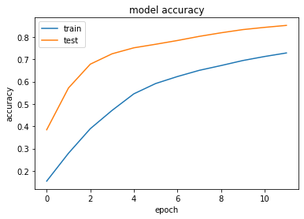

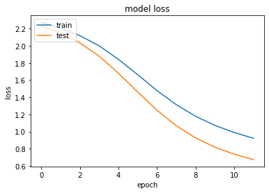

```python
# list all data in history
print(history.history.keys())
# summarize history for accuracy
plt.plot(history.history['accuracy'])
plt.plot(history.history['val_accuracy'])
plt.title('model accuracy')
plt.ylabel('accuracy')
plt.xlabel('epoch')
plt.legend(['train', 'test'], loc='upper left')
plt.show()
# summarize history for loss
plt.plot(history.history['loss'])
plt.plot(history.history['val_loss'])
plt.title('model loss')
plt.ylabel('loss')
plt.xlabel('epoch')
plt.legend(['train', 'test'], loc='upper left')
plt.show()
```

### When running the keras model with GPU, it has a train loss and accuracy of 0.9221 and 0.7281 and test loss and accuracy of 0.6738 and 0.8514. These results are very similar to when GPU was not used, which shows that GPU will not provide prediction improvements. Based on the plot, this model is also underfitting. However, the speed of the training and testing significantly increases from 1715s to only 94s. As a result, we should run it with GPU when available as it does not seem to cause any decrease in performance, and instead improve the speed.

```python
predictions = model.predict(x_test, verbose=0)
```

```python
yitest = np.argmax(y_test, axis=1)

yptest = np.argmax(predictions, axis=1)
print (yitest)
print (yptest)
```

```
[7 2 1 ... 4 5 6]
[7 2 1 ... 4 8 6]
```

```python
cfm = confusion_matrix(yitest, yptest)
print (cfm)
```

```
[[ 942    0    1    3    0    2   21    1   10    0]
 [   0 1084    3   10    0    2    5    0   30    1]
 [  20    6  885   12   13    0   34   24   37    1]
 [   5    8   33  896    0    8    6   24   21    9]
 [   2   10    4    0  847    0   31    2   11   75]
 [  29   15   10  146   32  571   25    8   40   16]
 [  25   20    8    0    8   17  879    0    1    0]
 [   1   39   32    1   17    0    2  885   11   40]
 [  13   30   11   69   12   14   14   15  775   21]
 [  16   21    7   15  140    2    5   41   12  750]]
```

```
Confusion matrix, without normalization
```

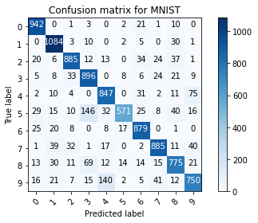

```python
plot_confusion_matrix(cfm, classes=range(10),
                      title='Confusion matrix for MNIST')
```

### The confusion matrix of the GPU and non-GPU experiment of the keras model is very similar and consistent with each other.

## Provided pytorch model (labpytorch2.ipynb) without GPU

### Below is the code to run the provided pytorch model. We will run and see its performance. Similar to the Keras model, the first step is to import the required libraries and extract the MNIST dataset as training and testing set.

```python
import time
import torch
import torch.nn as nn
import torchvision
import torchvision.transforms as transforms

from matplotlib import pyplot as plt
import numpy as np
from datetime import datetime
from sklearn.metrics import confusion_matrix
import itertools

# Device configuration
device = torch.device('cuda:0' if torch.cuda.is_available() else 'cpu')

# MNIST dataset
train_dataset = torchvision.datasets.MNIST(root='./data/',
                                           train=True,
                                           transform=transforms.ToTensor(),
                                           download=True)

test_dataset = torchvision.datasets.MNIST(root='./data/',
                                          train=False,
                                          transform= transforms.ToTensor())
```

```
6.0%
```

```
Downloading http://yann.lecun.com/exdb/mnist/train-images-idx3-ubyte.gz to ./data/MNIST/raw/train-images-idx3-ubyte.gz
```

```
100.1%
```

```
Extracting ./data/MNIST/raw/train-images-idx3-ubyte.gz to ./data/MNIST/raw
```

```
0.5%5%
```

```
Downloading http://yann.lecun.com/exdb/mnist/train-labels-idx1-ubyte.gz to ./data/MNIST/raw/train-labels-idx1-ubyte.gz
Extracting ./data/MNIST/raw/train-labels-idx1-ubyte.gz to ./data/MNIST/raw
Downloading http://yann.lecun.com/exdb/mnist/t10k-images-idx3-ubyte.gz to ./data/MNIST/raw/t10k-images-idx3-ubyte.gz
```

```
180.4%
```

```
Extracting ./data/MNIST/raw/t10k-images-idx3-ubyte.gz to ./data/MNIST/raw
Downloading http://yann.lecun.com/exdb/mnist/t10k-labels-idx1-ubyte.gz to ./data/MNIST/raw/t10k-labels-idx1-ubyte.gz
Extracting ./data/MNIST/raw/t10k-labels-idx1-ubyte.gz to ./data/MNIST/raw
Processing...
Done!
```

### Next, several functions are created for training, testing, and plotting purposes, such as to the plot() function and log_progress() function.

```python
'''Learning Curve Plot Utility'''
def plot(train_loss_history, val_loss_history, train_acc_history, val_acc_history):
  fig, axs = plt.subplots(1, 2, figsize=(11,5))

  ax = axs[0]
  ax.set_title("Model Loss", fontsize=12)
  ax.plot(train_loss_history, label="Training")
  ax.plot(val_loss_history,   label="Validation")
  ax.set_xlabel("Epoch",        fontsize=12)
  ax.set_ylabel("Average loss", fontsize=12)
  ax.legend(loc="best",         fontsize=12)

  ax = axs[1]
  ax.set_title("Model Accuracy", fontsize=12)
  ax.plot(train_acc_history, label="Training")
  ax.plot(val_acc_history,   label="Validation")
  ax.set_xlabel("Epoch",        fontsize=12)
  ax.set_ylabel("Accuracy",     fontsize=12)
  ax.set_ylim(0,1)
  ax.legend(loc="best",         fontsize=12)
```

```python
'''Learning progress utility'''
def log_progress(running_loss, curr_batch, batch_size, curr_epoch, total_epochs, dataloader):
    """
    Prints message logging progress through training.
    """
    progress = float(curr_batch + 1)/(float(len(dataloader.dataset)) / batch_size)
    log = "EPOCH [{}/{}]. Running Loss: {} Progress: {} % ".format(
        curr_epoch + 1, total_epochs, round(running_loss, 2), round(progress * 100, 2))
    print(log)
```

### Next, the hyperparameters are set and train and test data are loaded.

```python
# Hyperparameters
num_epochs = 6
num_classes = 10
batch_size = 100
learning_rate = 0.0001
```

```python
# Data loader
train_loader = torch.utils.data.DataLoader(dataset=train_dataset,
                                           batch_size=batch_size,
                                           shuffle=True)

test_loader = torch.utils.data.DataLoader(dataset=test_dataset,
                                          batch_size=batch_size,
                                          shuffle=False)
```

### Then, the model layers are created. In the model below, we are using two convolutional layers. In each layer, there is the convolution, batch normalization, activation, and maxpool.

```python
# Convolutional neural network (two convolutional layers)
class ConvNet(nn.Module):
    def __init__(self, num_classes=10):
        super(ConvNet, self).__init__()
        self.layer1 = nn.Sequential(
            nn.Conv2d(1, 16, kernel_size=5, stride=1, padding=2),
            nn.BatchNorm2d(16),
            nn.ReLU(),
            nn.MaxPool2d(kernel_size=2, stride=2)
            )
        self.layer2 = nn.Sequential(
            nn.Conv2d(16, 32, kernel_size=5, stride=1, padding=2),
            nn.BatchNorm2d(32),
            nn.ReLU(),
            nn.MaxPool2d(kernel_size=2, stride=2))
        self.fc = nn.Linear(7*7*32, num_classes)

    def forward(self, x):
        out = self.layer1(x)
        out = self.layer2(out)
        out = out.reshape(out.size(0), -1)
        out = self.fc(out)
        return out

model = ConvNet(num_classes).to(device)
```

### Next, the model is then trained and tested as below.

```python
# Loss and optimizer
criterion = nn.CrossEntropyLoss()
optimizer = torch.optim.Adam(model.parameters(), lr=learning_rate)

# Keep track of average losses, training accuracy and validation accuracy for each epoch
train_loss_history = np.zeros(num_epochs)
train_acc_history  = np.zeros(num_epochs)
val_loss_history   = np.zeros(num_epochs)
val_acc_history    = np.zeros(num_epochs)

start_time = datetime.now()

for epoch in range(num_epochs):

    # Place network in training mode
    model.train()

    # Initialize running epoch loss and number correctly classified
    running_loss   = 0.0
    num_correct    = 0.0
    total_images   = 0.0

    for batch_num, (inputs, labels) in enumerate(train_loader):
        # [inputs] and [labels] is one batch of images and their classes
        inputs = inputs.to(device)
        labels = labels.to(device)

        # Forward pass
        outputs = model(inputs)
        loss = criterion(outputs, labels)

        # Backward and optimize
        optimizer.zero_grad()
        loss.backward()
        optimizer.step()

        # Update statistics for this batch
        curr_loss = loss.item()
        _, preds = torch.max(outputs, 1)
        curr_images = labels.cpu().data.numpy().size
        curr_correct = torch.sum(preds == labels.data.reshape(-1))

        # Update running statistics for this epoch
        running_loss += curr_loss
        num_correct += curr_correct
        total_images += curr_images

        # Log Progress every 200 batches
        if (batch_num + 1) % 200 == 0:
          log_progress(running_loss, batch_num, batch_size, epoch, num_epochs, train_loader)

    # Update statistics for epoch
    train_loss_history[epoch] = curr_loss #running_loss / total_images
    train_acc_history[epoch]  = float(num_correct)  / float(total_images)
    print("Train Avg. Loss: [{}] Acc: {} on {} images".format(
        round(train_loss_history[epoch],4), round(train_acc_history[epoch],4), total_images) )

    # ============================ Validation ==============================
    print("Validating...")
    # Place network in testing mode (won't need to keep track of gradients)
    model.eval()

    running_loss   = 0.0
    num_correct    = 0.0
    total_images   = 0.0

    for batch_num, (inputs, labels) in enumerate(test_loader):
        inputs = inputs.to(device)
        labels = labels.to(device)

        # Propagate batch through network
        outputs  = model(inputs)
        loss     = criterion(outputs, labels.squeeze())
        _, preds = torch.max(outputs, 1)

        # Update statistics for this batch
        running_loss  += loss.item()
        num_correct   += torch.sum(preds == labels.data.reshape(-1))
        total_images  += labels.cpu().data.numpy().size

        # Log Progress every 200 batches
        if (batch_num + 1) % 200 == 0:
          log_progress(running_loss, batch_num, batch_size, epoch, num_epochs, test_loader)

    # Update statistics for validation data
    val_loss_history[epoch] = loss.item() #running_loss / total_images
    val_acc_history[epoch]  = float(num_correct)  / float(total_images)
    print("Val Avg. Loss: [{}] Acc: {} on {} images\n".format(
        round(val_loss_history[epoch],4), val_acc_history[epoch], total_images))

print("Time Elapsed: {} seconds".format((datetime.now() - start_time).total_seconds()))
```

```
EPOCH [1/6]. Running Loss: 184.41 Progress: 33.33 %
EPOCH [1/6]. Running Loss: 241.21 Progress: 66.67 %
EPOCH [1/6]. Running Loss: 277.97 Progress: 100.0 %
Train Avg. Loss: [0.122] Acc: 0.8938 on 60000.0 images
Validating...
Val Avg. Loss: [0.2022] Acc: 0.9645 on 10000.0 images

EPOCH [2/6]. Running Loss: 27.81 Progress: 33.33 %
EPOCH [2/6]. Running Loss: 50.74 Progress: 66.67 %
EPOCH [2/6]. Running Loss: 71.42 Progress: 100.0 %
Train Avg. Loss: [0.1179] Acc: 0.9699 on 60000.0 images
Validating...
Val Avg. Loss: [0.1036] Acc: 0.9775 on 10000.0 images

EPOCH [3/6]. Running Loss: 17.01 Progress: 33.33 %
EPOCH [3/6]. Running Loss: 33.09 Progress: 66.67 %
EPOCH [3/6]. Running Loss: 48.81 Progress: 100.0 %
Train Avg. Loss: [0.0896] Acc: 0.9787 on 60000.0 images
Validating...
Val Avg. Loss: [0.0805] Acc: 0.982 on 10000.0 images

EPOCH [4/6]. Running Loss: 13.55 Progress: 33.33 %
EPOCH [4/6]. Running Loss: 26.1 Progress: 66.67 %
EPOCH [4/6]. Running Loss: 38.56 Progress: 100.0 %
Train Avg. Loss: [0.0438] Acc: 0.9823 on 60000.0 images
Validating...
Val Avg. Loss: [0.0562] Acc: 0.9835 on 10000.0 images

EPOCH [5/6]. Running Loss: 12.25 Progress: 33.33 %
EPOCH [5/6]. Running Loss: 22.65 Progress: 66.67 %
EPOCH [5/6]. Running Loss: 32.4 Progress: 100.0 %
Train Avg. Loss: [0.0146] Acc: 0.9853 on 60000.0 images
Validating...
Val Avg. Loss: [0.0387] Acc: 0.9843 on 10000.0 images

EPOCH [6/6]. Running Loss: 9.29 Progress: 33.33 %
EPOCH [6/6]. Running Loss: 18.32 Progress: 66.67 %
EPOCH [6/6]. Running Loss: 28.39 Progress: 100.0 %
Train Avg. Loss: [0.0306] Acc: 0.9866 on 60000.0 images
Validating...
Val Avg. Loss: [0.0318] Acc: 0.9865 on 10000.0 images

Time Elapsed: 548.182731 seconds
```

## Learning curve plots

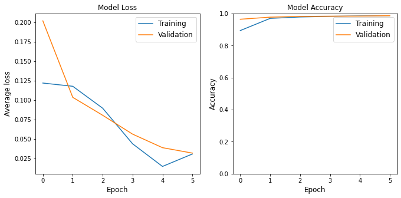

```python
plot(train_loss_history, val_loss_history, train_acc_history, val_acc_history)
```

```python
# Test the model
ytest = []
rtest = np.ones((0,10))
model.eval()  # eval mode (batchnorm uses moving mean/variance instead of mini-batch mean/variance)
with torch.no_grad():
    correct = 0
    total = 0
    for images, labels in test_loader:
        ytest = np.append(ytest, labels)
        images = images.to(device)
        labels = labels.to(device)
        outputs = model(images)
        _, predicted = torch.max(outputs.data, 1)
        total += labels.size(0)
        correct += (predicted == labels).sum().item()
        rtest = np.append(rtest, outputs, axis=0)
print('Test Accuracy of the model on the 10000 test images: {} %'.format(100 * correct / total))
```

```
Test Accuracy of the model on the 10000 test images: 98.65 %
```

```
Confusion matrix, without normalization
```

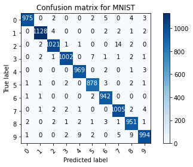

```python
cfm = confusion_matrix(np.argmax (rtest,axis=1), ytest)
plot_confusion_matrix(cfm, classes=range(10),
                      title='Confusion matrix for MNIST')
```

### Next, we will try to run this pytorch model with GPU to see the differences that it may cause.

## Provided pytorch model (labpytorch2.ipynb) with GPU

```python
# Loss and optimizer
criterion = nn.CrossEntropyLoss()
optimizer = torch.optim.Adam(model.parameters(), lr=learning_rate)

# Keep track of average losses, training accuracy and validation accuracy for each epoch
train_loss_history = np.zeros(num_epochs)
train_acc_history  = np.zeros(num_epochs)
val_loss_history   = np.zeros(num_epochs)
val_acc_history    = np.zeros(num_epochs)

start_time = datetime.now()

for epoch in range(num_epochs):

    # Place network in training mode
    model.train()

    # Initialize running epoch loss and number correctly classified
    running_loss   = 0.0
    num_correct    = 0.0
    total_images   = 0.0

    for batch_num, (inputs, labels) in enumerate(train_loader):
        # [inputs] and [labels] is one batch of images and their classes
        inputs = inputs.to(device)
        labels = labels.to(device)

        # Forward pass
        outputs = model(inputs)
        loss = criterion(outputs, labels)

        # Backward and optimize
        optimizer.zero_grad()
        loss.backward()
        optimizer.step()

        # Update statistics for this batch
        curr_loss = loss.item()
        _, preds = torch.max(outputs, 1)
        curr_images = labels.cpu().data.numpy().size
        curr_correct = torch.sum(preds == labels.data.reshape(-1))

        # Update running statistics for this epoch
        running_loss += curr_loss
        num_correct += curr_correct
        total_images += curr_images

        # Log Progress every 200 batches
        if (batch_num + 1) % 200 == 0:
          log_progress(running_loss, batch_num, batch_size, epoch, num_epochs, train_loader)

    # Update statistics for epoch
    train_loss_history[epoch] = curr_loss #running_loss / total_images
    train_acc_history[epoch]  = float(num_correct)  / float(total_images)
    print("Train Avg. Loss: [{}] Acc: {} on {} images".format(
        round(train_loss_history[epoch],4), round(train_acc_history[epoch],4), total_images) )

    # ============================ Validation ==============================
    print("Validating...")
    # Place network in testing mode (won't need to keep track of gradients)
    model.eval()

    running_loss   = 0.0
    num_correct    = 0.0
    total_images   = 0.0

    for batch_num, (inputs, labels) in enumerate(test_loader):
        inputs = inputs.to(device)
        labels = labels.to(device)

        # Propagate batch through network
        outputs  = model(inputs)
        loss     = criterion(outputs, labels.squeeze())
        _, preds = torch.max(outputs, 1)

        # Update statistics for this batch
        running_loss  += loss.item()
        num_correct   += torch.sum(preds == labels.data.reshape(-1))
        total_images  += labels.cpu().data.numpy().size

        # Log Progress every 200 batches
        if (batch_num + 1) % 200 == 0:
          log_progress(running_loss, batch_num, batch_size, epoch, num_epochs, test_loader)

    # Update statistics for validation data
    val_loss_history[epoch] = loss.item() #running_loss / total_images
    val_acc_history[epoch]  = float(num_correct)  / float(total_images)
    print("Val Avg. Loss: [{}] Acc: {} on {} images\n".format(
        round(val_loss_history[epoch],4), val_acc_history[epoch], total_images))

print("Time Elapsed: {} seconds".format((datetime.now() - start_time).total_seconds()))
```

```
EPOCH [1/6]. Running Loss: 182.82 Progress: 33.33 %
EPOCH [1/6]. Running Loss: 242.68 Progress: 66.67 %
EPOCH [1/6]. Running Loss: 280.86 Progress: 100.0 %
Train Avg. Loss: [0.1478] Acc: 0.8919 on 60000.0 images
Validating...
Val Avg. Loss: [0.2343] Acc: 0.963 on 10000.0 images

EPOCH [2/6]. Running Loss: 28.49 Progress: 33.33 %
EPOCH [2/6]. Running Loss: 52.73 Progress: 66.67 %
EPOCH [2/6]. Running Loss: 73.17 Progress: 100.0 %
Train Avg. Loss: [0.089] Acc: 0.9699 on 60000.0 images
Validating...
Val Avg. Loss: [0.122] Acc: 0.9758 on 10000.0 images

EPOCH [3/6]. Running Loss: 17.87 Progress: 33.33 %
EPOCH [3/6]. Running Loss: 33.43 Progress: 66.67 %
EPOCH [3/6]. Running Loss: 47.98 Progress: 100.0 %
Train Avg. Loss: [0.0501] Acc: 0.9793 on 60000.0 images
Validating...
Val Avg. Loss: [0.066] Acc: 0.9821 on 10000.0 images

EPOCH [4/6]. Running Loss: 12.69 Progress: 33.33 %
EPOCH [4/6]. Running Loss: 25.12 Progress: 66.67 %
EPOCH [4/6]. Running Loss: 36.94 Progress: 100.0 %
Train Avg. Loss: [0.0416] Acc: 0.9836 on 60000.0 images
Validating...
Val Avg. Loss: [0.045] Acc: 0.9851 on 10000.0 images

EPOCH [5/6]. Running Loss: 10.56 Progress: 33.33 %
EPOCH [5/6]. Running Loss: 20.97 Progress: 66.67 %
EPOCH [5/6]. Running Loss: 30.84 Progress: 100.0 %
Train Avg. Loss: [0.0802] Acc: 0.9861 on 60000.0 images
Validating...
Val Avg. Loss: [0.0451] Acc: 0.9866 on 10000.0 images

EPOCH [6/6]. Running Loss: 9.03 Progress: 33.33 %
EPOCH [6/6]. Running Loss: 17.88 Progress: 66.67 %
EPOCH [6/6]. Running Loss: 26.57 Progress: 100.0 %
Train Avg. Loss: [0.0384] Acc: 0.9876 on 60000.0 images
Validating...
Val Avg. Loss: [0.0265] Acc: 0.9873 on 10000.0 images

Time Elapsed: 78.169121 seconds
```

## Learning curve plots

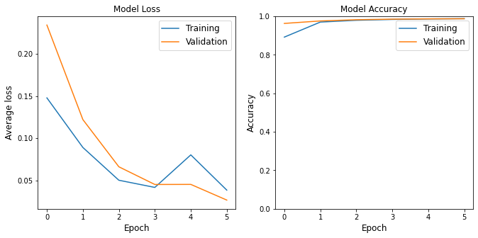

```python
plot(train_loss_history, val_loss_history, train_acc_history, val_acc_history)
```

```python
# Test the model
ytest = []
rtest = np.ones((0,10))
model.eval()  # eval mode (batchnorm uses moving mean/variance instead of mini-batch mean/variance)
with torch.no_grad():
    correct = 0
    total = 0
    for images, labels in test_loader:
        ytest = np.append(ytest, labels)
        images = images.to(device)
        labels = labels.to(device)
        outputs = model(images)
        _, predicted = torch.max(outputs.data, 1)
        total += labels.size(0)
        correct += (predicted == labels).sum().item()
        rtest = np.append(rtest, outputs.cpu(), axis=0)
print('Test Accuracy of the model on the 10000 test images: {} %'.format(100 * correct / total))
```

```
Test Accuracy of the model on the 10000 test images: 98.73 %
```

```
Confusion matrix, without normalization
```

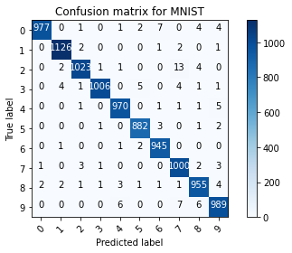

```python
cfm = confusion_matrix(np.argmax (rtest,axis=1), ytest)
plot_confusion_matrix(cfm, classes=range(10),
                      title='Confusion matrix for MNIST')
```

### Looking at the results of the pytorch model running with GPU or not, it looks like the main advantage is speed. The experiment with GPU ran for 78s, while without a GPU it ran for 548s. This is a huge improvement, which makes using the GPU a huge advantage. There seems to be no downside of using it with GPU. The testing accuracy between the two are similar: 98.73% with GPU and 98.65% without GPU. Both of their confusion matrix are also similar.

### In this next step, we will try to create the pytorch model in Keras and vice veras to see if there will be any performance differences to conclude on which model is better, and to even identify on which framework is better.

## Provided Keras model on Pytorch (labpytorch3.ipynb)

### The code below shows the keras model created in PyTorch. The first step is in extracting the MNIST data as training and testing dataset.

```python
# Device configuration
device = torch.device('cuda:0' if torch.cuda.is_available() else 'cpu')

# MNIST dataset
train_dataset = torchvision.datasets.MNIST(root='./data/',
                                           train=True,
                                           transform=transforms.ToTensor(),
                                           download=True)

test_dataset = torchvision.datasets.MNIST(root='./data/',
                                          train=False,
                                          transform= transforms.ToTensor())
```

```
Downloading http://yann.lecun.com/exdb/mnist/train-images-idx3-ubyte.gz to ./data/MNIST/raw/train-images-idx3-ubyte.gz
```

```
Extracting ./data/MNIST/raw/train-images-idx3-ubyte.gz to ./data/MNIST/raw
Downloading http://yann.lecun.com/exdb/mnist/train-labels-idx1-ubyte.gz to ./data/MNIST/raw/train-labels-idx1-ubyte.gz
```

```
Extracting ./data/MNIST/raw/train-labels-idx1-ubyte.gz to ./data/MNIST/raw
Downloading http://yann.lecun.com/exdb/mnist/t10k-images-idx3-ubyte.gz to ./data/MNIST/raw/t10k-images-idx3-ubyte.gz
```

```
Extracting ./data/MNIST/raw/t10k-images-idx3-ubyte.gz to ./data/MNIST/raw
Downloading http://yann.lecun.com/exdb/mnist/t10k-labels-idx1-ubyte.gz to ./data/MNIST/raw/t10k-labels-idx1-ubyte.gz
```

```
Extracting ./data/MNIST/raw/t10k-labels-idx1-ubyte.gz to ./data/MNIST/raw
Processing...



Done!
```

### Next, we created some functions that will be used to train and plot the results.

```python
'''Learning Curve Plot Utility'''
def plot(train_loss_history, val_loss_history, train_acc_history, val_acc_history):
  fig, axs = plt.subplots(1, 2, figsize=(11,5))

  ax = axs[0]
  ax.set_title("Model Loss", fontsize=12)
  ax.plot(train_loss_history, label="Training")
  ax.plot(val_loss_history,   label="Validation")
  ax.set_xlabel("Epoch",        fontsize=12)
  ax.set_ylabel("Average loss", fontsize=12)
  ax.legend(loc="best",         fontsize=12)

  ax = axs[1]
  ax.set_title("Model Accuracy", fontsize=12)
  ax.plot(train_acc_history, label="Training")
  ax.plot(val_acc_history,   label="Validation")
  ax.set_xlabel("Epoch",        fontsize=12)
  ax.set_ylabel("Accuracy",     fontsize=12)
  ax.set_ylim(0,1)
  ax.legend(loc="best",         fontsize=12)
```

```python
'''Learning progress utility'''
def log_progress(running_loss, curr_batch, batch_size, curr_epoch, total_epochs, dataloader):
    """
    Prints message logging progress through training.
    """
    progress = float(curr_batch + 1)/(float(len(dataloader.dataset)) / batch_size)
    log = "EPOCH [{}/{}]. Running Loss: {} Progress: {} % ".format(
        curr_epoch + 1, total_epochs, round(running_loss, 2), round(progress * 100, 2))
    print(log)
```

```python
#  preserntation for a confusion matrix

def plot_confusion_matrix(cm, classes,
                          normalize=False,
                          title='Confusion matrix',
                          cmap=plt.cm.Blues):
    """
    This function prints and plots the confusion matrix.
    Normalization can be applied by setting `normalize=True`.
    """
    if normalize:
        cm = cm.astype('float') / cm.sum(axis=1)[:, np.newaxis]
        print("Normalized confusion matrix")
    else:
        print('Confusion matrix, without normalization')

    #print(cm)

    plt.imshow(cm, interpolation='nearest', cmap=cmap)
    plt.title(title)
    plt.colorbar()
    tick_marks = np.arange(len(classes))
    plt.xticks(tick_marks, classes, rotation=45)
    plt.yticks(tick_marks, classes)

    fmt = '.2f' if normalize else 'd'
    thresh = cm.max() / 2.
    for i, j in itertools.product(range(cm.shape[0]), range(cm.shape[1])):
        plt.text(j, i, format(cm[i, j], fmt),
                 horizontalalignment="center",
                 color="white" if cm[i, j] > thresh else "black")

    plt.ylabel('True label')
    plt.xlabel('Predicted label')
    plt.tight_layout()
```

### In this step, the hyperparameters are set. There are some changes compared to the original pytorch model.

```python
# Hyperparameters
num_epochs = 12 # changed from 6
num_classes = 10
batch_size = 128 # changed from 100
learning_rate = 1.0 # changed from 0.0001
```

```python
# Data loader
train_loader = torch.utils.data.DataLoader(dataset=train_dataset,
                                           batch_size=batch_size,
                                           shuffle=True)

test_loader = torch.utils.data.DataLoader(dataset=test_dataset,
                                          batch_size=batch_size,
                                          shuffle=False)
```

## Model

### In this step, we created the CNN model of the keras demo model. At the top, we can see the model that was created based on the keras structure shown on the comment block below. There are a total of two convolutional layers made up of convolution and activation function. Then, there is the maxpool layer, dense layer in keras that is equivalent to linear in pytorch, the dropouts layer, and the softmax. The difficult part is in determining the strides and padding for convolution and maxpool. The stride should be set as 1 as it is the default value, while the padding are calculated by the formula width_output = (width_input - filter_size + 2 * padding)/stride + 1. The different layers are first created, and are then combined in the forward function to have a similar order to the model's implementation in keras.

```python
# Convolutional neural network (two convolutional layers)
class ConvNet(nn.Module):
    def __init__(self, num_classes=10):
        super(ConvNet, self).__init__()
        self.layer1 = nn.Sequential(
            nn.Conv2d(1, 32, kernel_size=3, stride=1, padding=0),
            nn.ReLU()
            )
        self.layer2 = nn.Sequential(
            nn.Conv2d(32, 64, kernel_size=3, stride=1, padding=0),
            nn.ReLU()
            )
        self.max_pool = nn.MaxPool2d(kernel_size=2)
        self.fc1 = nn.Sequential(
            nn.Linear(12*12*64, 128),
            nn.ReLU(),
            )
        self.fc2 = nn.Linear(128, num_classes)
        self.drop_out5 = nn.Dropout(p=0.5)
        self.drop_out25 = nn.Dropout(p=0.25)
        self.flat = nn.Flatten()
        self.soft_max = nn.Softmax()


# model = Sequential()
# model.add(Conv2D(32, kernel_size=(3, 3),
#                  activation='relu',
#                  input_shape=input_shape))
# model.add(Conv2D(64, (3, 3), activation='relu'))
# model.add(MaxPooling2D(pool_size=(2, 2))) default to valid (no padding)?
# model.add(Dropout(0.25))
# model.add(Flatten())
# model.add(Dense(128, activation='relu'))
# model.add(Dropout(0.5))
# model.add(Dense(num_classes, activation='softmax'))


    def forward(self, x):
        out = self.layer1(x) # Conv2D, relu, input size 28 output size 26
        out = self.layer2(out) # Conv2D, relu, in 26 out 24
        out = self.max_pool(out) # MaxPool2D, in 24 out 12
        out = self.drop_out25(out) # Dropout 0.25
        out = out.reshape(out.size(0), -1) # Flatten
        out = self.fc1(out) # Dense
        out = self.drop_out5(out) # Dropout 0.5
        out = self.fc2(out) # Dense
        out = self.soft_max(out) # Softmax
        return out

model = ConvNet(num_classes).to(device)
```

## Training

### In this section, the model is trained. Since this section is created based on the pytorch demo model, the only change needed is to change the optimizers to Adadelta with the specified learning rate.

```python
# Loss and optimizer
criterion = nn.CrossEntropyLoss()
optimizer = torch.optim.Adadelta(model.parameters(), lr=learning_rate) # Changed to Adadelta with lr=1.0

# Keep track of average losses, training accuracy and validation accuracy for each epoch
train_loss_history = np.zeros(num_epochs)
train_acc_history  = np.zeros(num_epochs)
val_loss_history   = np.zeros(num_epochs)
val_acc_history    = np.zeros(num_epochs)

start_time = datetime.now()

for epoch in range(num_epochs):

    # Place network in training mode
    model.train()

    # Initialize running epoch loss and number correctly classified
    running_loss   = 0.0
    num_correct    = 0.0
    total_images   = 0.0

    for batch_num, (inputs, labels) in enumerate(train_loader):
        # [inputs] and [labels] is one batch of images and their classes
        inputs = inputs.to(device)
        labels = labels.to(device)

        # Forward pass
        outputs = model(inputs)
        loss = criterion(outputs, labels)

        # Backward and optimize
        optimizer.zero_grad()
        loss.backward()
        optimizer.step()

        # Update statistics for this batch
        curr_loss = loss.item()
        _, preds = torch.max(outputs, 1)
        curr_images = labels.cpu().data.numpy().size
        curr_correct = torch.sum(preds == labels.data.reshape(-1))

        # Update running statistics for this epoch
        running_loss += curr_loss
        num_correct += curr_correct
        total_images += curr_images

        # Log Progress every 200 batches
        if (batch_num + 1) % 200 == 0:
          log_progress(running_loss, batch_num, batch_size, epoch, num_epochs, train_loader)

    # Update statistics for epoch
    train_loss_history[epoch] = curr_loss #running_loss / total_images
    train_acc_history[epoch]  = float(num_correct)  / float(total_images)
    print("Train Avg. Loss: [{}] Acc: {} on {} images".format(
        round(train_loss_history[epoch],4), round(train_acc_history[epoch],4), total_images) )

    # ============================ Validation ==============================
    print("Validating...")
    # Place network in testing mode (won't need to keep track of gradients)
    model.eval()

    running_loss   = 0.0
    num_correct    = 0.0
    total_images   = 0.0

    for batch_num, (inputs, labels) in enumerate(test_loader):
        inputs = inputs.to(device)
        labels = labels.to(device)

        # Propagate batch through network
        outputs  = model(inputs)
        loss     = criterion(outputs, labels.squeeze())
        _, preds = torch.max(outputs, 1)

        # Update statistics for this batch
        running_loss  += loss.item()
        num_correct   += torch.sum(preds == labels.data.reshape(-1))
        total_images  += labels.cpu().data.numpy().size

        # Log Progress every 200 batches
        if (batch_num + 1) % 200 == 0:
          log_progress(running_loss, batch_num, batch_size, epoch, num_epochs, test_loader)

    # Update statistics for validation data
    val_loss_history[epoch] = loss.item() #running_loss / total_images
    val_acc_history[epoch]  = float(num_correct)  / float(total_images)
    print("Val Avg. Loss: [{}] Acc: {} on {} images\n".format(
        round(val_loss_history[epoch],4), val_acc_history[epoch], total_images))

print("Time Elapsed: {} seconds".format((datetime.now() - start_time).total_seconds()))
```

```
EPOCH [1/12]. Running Loss: 346.21 Progress: 42.67 %
EPOCH [1/12]. Running Loss: 657.72 Progress: 85.33 %
Train Avg. Loss: [1.5285] Acc: 0.8392 on 60000.0 images
Validating...
Val Avg. Loss: [1.4613] Acc: 0.9587 on 10000.0 images

EPOCH [2/12]. Running Loss: 304.21 Progress: 42.67 %
EPOCH [2/12]. Running Loss: 606.54 Progress: 85.33 %
Train Avg. Loss: [1.4885] Acc: 0.9477 on 60000.0 images
Validating...
Val Avg. Loss: [1.4612] Acc: 0.9741 on 10000.0 images

EPOCH [3/12]. Running Loss: 300.45 Progress: 42.67 %
EPOCH [3/12]. Running Loss: 600.37 Progress: 85.33 %
Train Avg. Loss: [1.4935] Acc: 0.962 on 60000.0 images
Validating...
Val Avg. Loss: [1.4612] Acc: 0.9796 on 10000.0 images

EPOCH [4/12]. Running Loss: 298.99 Progress: 42.67 %
EPOCH [4/12]. Running Loss: 597.52 Progress: 85.33 %
Train Avg. Loss: [1.5052] Acc: 0.9684 on 60000.0 images
Validating...
Val Avg. Loss: [1.4612] Acc: 0.9781 on 10000.0 images

EPOCH [5/12]. Running Loss: 297.81 Progress: 42.67 %
EPOCH [5/12]. Running Loss: 595.87 Progress: 85.33 %
Train Avg. Loss: [1.4946] Acc: 0.972 on 60000.0 images
Validating...
Val Avg. Loss: [1.4612] Acc: 0.9812 on 10000.0 images

EPOCH [6/12]. Running Loss: 297.07 Progress: 42.67 %
EPOCH [6/12]. Running Loss: 594.41 Progress: 85.33 %
Train Avg. Loss: [1.4903] Acc: 0.9758 on 60000.0 images
Validating...
Val Avg. Loss: [1.4612] Acc: 0.9842 on 10000.0 images

EPOCH [7/12]. Running Loss: 297.16 Progress: 42.67 %
EPOCH [7/12]. Running Loss: 594.24 Progress: 85.33 %
Train Avg. Loss: [1.4741] Acc: 0.9765 on 60000.0 images
Validating...
```

[output cut: 18 more lines]

```
Val Avg. Loss: [1.4612] Acc: 0.9863 on 10000.0 images

EPOCH [11/12]. Running Loss: 295.98 Progress: 42.67 %
EPOCH [11/12]. Running Loss: 591.81 Progress: 85.33 %
Train Avg. Loss: [1.4638] Acc: 0.9818 on 60000.0 images
Validating...
Val Avg. Loss: [1.4612] Acc: 0.9884 on 10000.0 images

EPOCH [12/12]. Running Loss: 295.76 Progress: 42.67 %
EPOCH [12/12]. Running Loss: 591.42 Progress: 85.33 %
Train Avg. Loss: [1.482] Acc: 0.9828 on 60000.0 images
Validating...
Val Avg. Loss: [1.4612] Acc: 0.9876 on 10000.0 images

Time Elapsed: 1578.35037 seconds
```

## Learning curve plots

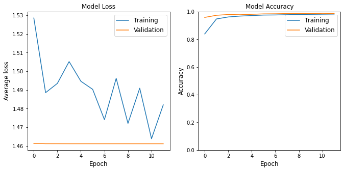

```python
plot(train_loss_history, val_loss_history, train_acc_history, val_acc_history)
```

```python
# Test the model
ytest = []
rtest = np.ones((0,10))
model.eval()  # eval mode (batchnorm uses moving mean/variance instead of mini-batch mean/variance)
with torch.no_grad():
    correct = 0
    total = 0
    for images, labels in test_loader:
        ytest = np.append(ytest, labels)
        images = images.to(device)
        labels = labels.to(device)
        outputs = model(images)
        _, predicted = torch.max(outputs.data, 1)
        total += labels.size(0)
        correct += (predicted == labels).sum().item()
        rtest = np.append(rtest, outputs, axis=0)
print('Test Accuracy of the model on the 10000 test images: {} %'.format(100 * correct / total))
```

```
Test Accuracy of the model on the 10000 test images: 98.76 %
```

```
Confusion matrix, without normalization
```

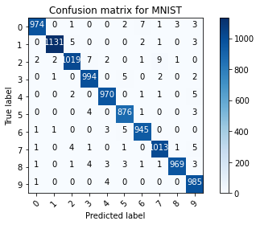

```python
cfm = confusion_matrix(np.argmax (rtest,axis=1), ytest)
plot_confusion_matrix(cfm, classes=range(10),
                      title='Confusion matrix for MNIST')
```

### Looking at the confusion matrix, we can see that it has a pretty good performance. The blue boxes are along the diagonal of correct predictions, and there are no major misclassifications shown in the matrix. Compared to this model's implementation in Keras, it looks to perform much better in pytorch.

```python
# Save the model checkpoint
torch.save(model.state_dict(), 'model.ckpt')
```

## Provided Pytorch model on Keras (labkeras3.ipynb)

```python
from __future__ import print_function
import keras
from keras.datasets import mnist
from keras.models import Sequential
from keras.layers import Dense, Dropout, Flatten
from keras.layers import Conv2D, MaxPooling2D, BatchNormalization
from keras import backend as K
import time
from datetime import datetime

start_time = datetime.now()

batch_size = 100
num_classes = 10
epochs = 6

# input image dimensions
img_rows, img_cols = 28, 28

# the data, split between train and test sets
(x_train, y_train), (x_test, y_test) = mnist.load_data()

if K.image_data_format() == 'channels_first':
    x_train = x_train.reshape(x_train.shape[0], 1, img_rows, img_cols)
    x_test = x_test.reshape(x_test.shape[0], 1, img_rows, img_cols)
    input_shape = (1, img_rows, img_cols)
else:
    x_train = x_train.reshape(x_train.shape[0], img_rows, img_cols, 1)
    x_test = x_test.reshape(x_test.shape[0], img_rows, img_cols, 1)
    input_shape = (img_rows, img_cols, 1)

x_train = x_train.astype('float32')
x_test = x_test.astype('float32')
x_train /= 255
x_test /= 255
print('x_train shape:', x_train.shape)
print(x_train.shape[0], 'train samples')
print(x_test.shape[0], 'test samples')

# convert class vectors to binary class matrices
y_train = keras.utils.to_categorical(y_train, num_classes)
y_test = keras.utils.to_categorical(y_test, num_classes)

model = Sequential()
#model.add(ZeroPadding2D(padding=(2, 2))) # Padding of 2
model.add(Conv2D(16, kernel_size=(5, 5),
                 strides=(1, 1),
                 activation='relu',
                 padding="same",
                 input_shape=input_shape))
model.add(BatchNormalization())
model.add(MaxPooling2D(pool_size=(2, 2), strides=(2, 2), padding="same"))
#model.add(ZeroPadding2D(padding=(2, 2))) # Padding of 2
model.add(Conv2D(32, kernel_size=(5, 5),
                 strides=(1, 1),
                 activation='relu',
                 padding="same"))
model.add(BatchNormalization())
model.add(MaxPooling2D(pool_size=(2, 2), strides=(2, 2), padding="same"))
model.add(Flatten())
#model.add(Dense(num_classes))
#model.add(Dense(128, activation='relu'))
model.add(Dense(num_classes, activation='softmax')) # Should I have softmax here?

model.compile(loss=keras.losses.categorical_crossentropy,
              optimizer=keras.optimizers.Adam(learning_rate=0.0001),
              metrics=['accuracy']) # updated to Adam and learning rate

history = model.fit(x_train, y_train,
          batch_size=batch_size,
          epochs=epochs,
          verbose=1,
          validation_data=(x_test, y_test))
score = model.evaluate(x_test, y_test, verbose=0)
print('Test loss:', score[0])
print('Test accuracy:', score[1])

# # Convolutional neural network (two convolutional layers)
# class ConvNet(nn.Module):
#     def __init__(self, num_classes=10):
#         super(ConvNet, self).__init__()
#         self.layer1 = nn.Sequential(
#             nn.Conv2d(1, 16, kernel_size=5, stride=1, padding=2),
#             nn.BatchNorm2d(16),
#             nn.ReLU(),
#             nn.MaxPool2d(kernel_size=2, stride=2)
#             )
#         self.layer2 = nn.Sequential(
#             nn.Conv2d(16, 32, kernel_size=5, stride=1, padding=2),
#             nn.BatchNorm2d(32),
#             nn.ReLU(),
#             nn.MaxPool2d(kernel_size=2, stride=2))
#         self.fc = nn.Linear(7*7*32, num_classes)

#     def forward(self, x):
#         out = self.layer1(x)
#         out = self.layer2(out)
#         out = out.reshape(out.size(0), -1)
#         out = self.fc(out)
#         return out

# model = ConvNet(num_classes).to(device)

print("Time Elapsed: {} seconds".format((datetime.now() - start_time).total_seconds()))
```

```
x_train shape: (60000, 28, 28, 1)
60000 train samples
10000 test samples
Test loss: 0.0451040081679821
Test accuracy: 0.98580002784729
Time Elapsed: 503.536414 seconds
```

```
dict_keys(['loss', 'accuracy', 'val_loss', 'val_accuracy'])
```

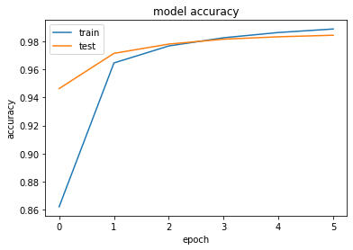

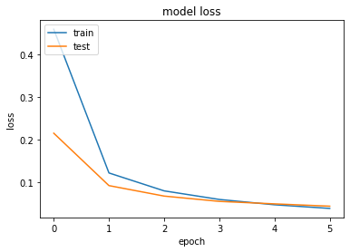

```python
# list all data in history
print(history.history.keys())
# summarize history for accuracy
plt.plot(history.history['accuracy'])
plt.plot(history.history['val_accuracy'])
plt.title('model accuracy')
plt.ylabel('accuracy')
plt.xlabel('epoch')
plt.legend(['train', 'test'], loc='upper left')
plt.show()
# summarize history for loss
plt.plot(history.history['loss'])
plt.plot(history.history['val_loss'])
plt.title('model loss')
plt.ylabel('loss')
plt.xlabel('epoch')
plt.legend(['train', 'test'], loc='upper left')
plt.show()
```

### From the results above, we can see that the train loss and accuracy is 0.0409 and 0.9883, while the test loss and accuracy is 0.0451 and 0.9858. This shows that this is a great model. Based on the plots, we can see that the model is great, neither overfitting nor underfitting. Compared to the original pytorch model that has 98.65% test accuracy, this model in keras has a similar test accuracy of 98.58%. Both of them are very good. Both models also shows a good plot (neither overfitting nor underfitting). In terms of training and testing speed, the original pytorch model requires 548 seconds while this experiment in keras requires 503 seconds. Running it in Keras is slightly faster, but not too significant. As a result, there seem to be not too much difference in running this model in Pytorch or Keras.

```python
predictions = model.predict(x_test, verbose=0)
```

```python
yitest = np.argmax(y_test, axis=1)

yptest = np.argmax(predictions, axis=1)
print (yitest)
print (yptest)
```

```
[7 2 1 ... 4 5 6]
[7 2 1 ... 4 5 6]
```

```python
cfm = confusion_matrix(yitest, yptest)
print (cfm)
```

```
[[ 974    0    0    1    0    0    3    1    1    0]
 [   0 1128    3    0    0    0    2    1    1    0]
 [   1    0 1021    2    1    0    1    4    1    1]
 [   0    0    3  991    0    9    0    4    2    1]
 [   0    1    0    0  970    0    1    2    1    7]
 [   2    0    1    4    0  883    1    0    1    0]
 [   5    4    0    0    1    7  939    0    2    0]
 [   0    3   14    2    1    1    0 1001    1    5]
 [   3    0    3    2    1    5    1    1  955    3]
 [   2    3    1    2    5    6    0    5    4  981]]
```

```
Confusion matrix, without normalization
```

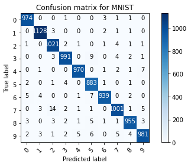

```python
plot_confusion_matrix(cfm, classes=range(10),
                      title='Confusion matrix for MNIST')
```

### Looking at the confusion matrix, we can see that most predictions are correct. When comparing this matrix with the experiment ran in Pytorch, there are barely any difference. This model has a similar performance in both Keras and Pytorch.

# Section 2

### In this section, we will be creating a CNN model in pytorch that will have the best test prediction compared to the models that we have in Section 1. In the first section, we are able to get 98.65% test accuracy, which is very good. We will attempt to modify the model to have an even better validation accuracy.

### Looking at the loss plot through the epoch in the original model, we can see that the loss is still decreasing. It looks like the model is not able to converge to have the best prediction given the learning rate in the limited epoch of only 6. So, we will try to increase the learning rate to have a better model, but it should not be too big or the model will overfit. Then, we will try to change the number of channels of the two convolutional layers. The layers now have channel 1 to 16, then 16 to 32. We will try to experiment if there are better number of channels that can have an stronger model.

### Next, we notice that in the dense layer of the original model, it only transform the output of 7*7*32 to the number of classes. We will try to create another layer and experiment with the number of outputs/channels to find out the best model. In the dense layer, we will also create a dropout layer. The dropout layer allows to prevent overfitting, which may help in making better label predictions for unseen data. The dropout parameter will need to be experimented with. Finally, we will try to add a softmax function in the final layer. This is to allow probability distribution when making predictions.

### Above is the plan that we will try to perform. Hopefully, we will be able to have an even better validation accuracy than the original model.

### In the first step it is about importing libraries and importing the MNIST dataset as training and testing data.

```python
import time
import torch
import torch.nn as nn
import torchvision
import torchvision.transforms as transforms

from matplotlib import pyplot as plt
import numpy as np
from datetime import datetime
from sklearn.metrics import confusion_matrix
import itertools

# Device configuration
device = torch.device('cuda:0' if torch.cuda.is_available() else 'cpu')

# MNIST dataset
train_dataset = torchvision.datasets.MNIST(root='./data/',
                                           train=True,
                                           transform=transforms.ToTensor(),
                                           download=True)

test_dataset = torchvision.datasets.MNIST(root='./data/',
                                          train=False,
                                          transform= transforms.ToTensor())
```

```
Downloading http://yann.lecun.com/exdb/mnist/train-images-idx3-ubyte.gz to ./data/MNIST/raw/train-images-idx3-ubyte.gz
```

```
Extracting ./data/MNIST/raw/train-images-idx3-ubyte.gz to ./data/MNIST/raw
Downloading http://yann.lecun.com/exdb/mnist/train-labels-idx1-ubyte.gz to ./data/MNIST/raw/train-labels-idx1-ubyte.gz
```

```
Extracting ./data/MNIST/raw/train-labels-idx1-ubyte.gz to ./data/MNIST/raw
Downloading http://yann.lecun.com/exdb/mnist/t10k-images-idx3-ubyte.gz to ./data/MNIST/raw/t10k-images-idx3-ubyte.gz
```

```
Extracting ./data/MNIST/raw/t10k-images-idx3-ubyte.gz to ./data/MNIST/raw
Downloading http://yann.lecun.com/exdb/mnist/t10k-labels-idx1-ubyte.gz to ./data/MNIST/raw/t10k-labels-idx1-ubyte.gz
```

```
Extracting ./data/MNIST/raw/t10k-labels-idx1-ubyte.gz to ./data/MNIST/raw
Processing...
Done!
```

### Next, several functions are created for plotting and training purposes.

```python
'''Learning Curve Plot Utility'''
def plot(train_loss_history, val_loss_history, train_acc_history, val_acc_history):
  fig, axs = plt.subplots(1, 2, figsize=(11,5))

  ax = axs[0]
  ax.set_title("Model Loss", fontsize=12)
  ax.plot(train_loss_history, label="Training")
  ax.plot(val_loss_history,   label="Validation")
  ax.set_xlabel("Epoch",        fontsize=12)
  ax.set_ylabel("Average loss", fontsize=12)
  ax.legend(loc="best",         fontsize=12)

  ax = axs[1]
  ax.set_title("Model Accuracy", fontsize=12)
  ax.plot(train_acc_history, label="Training")
  ax.plot(val_acc_history,   label="Validation")
  ax.set_xlabel("Epoch",        fontsize=12)
  ax.set_ylabel("Accuracy",     fontsize=12)
  ax.set_ylim(0,1)
  ax.legend(loc="best",         fontsize=12)
```

```python
'''Learning progress utility'''
def log_progress(running_loss, curr_batch, batch_size, curr_epoch, total_epochs, dataloader):
    """
    Prints message logging progress through training.
    """
    progress = float(curr_batch + 1)/(float(len(dataloader.dataset)) / batch_size)
    log = "EPOCH [{}/{}]. Running Loss: {} Progress: {} % ".format(
        curr_epoch + 1, total_epochs, round(running_loss, 2), round(progress * 100, 2))
    print(log)
```

```python
#  preserntation for a confusion matrix

def plot_confusion_matrix(cm, classes,
                          normalize=False,
                          title='Confusion matrix',
                          cmap=plt.cm.Blues):
    """
    This function prints and plots the confusion matrix.
    Normalization can be applied by setting `normalize=True`.
    """
    if normalize:
        cm = cm.astype('float') / cm.sum(axis=1)[:, np.newaxis]
        print("Normalized confusion matrix")
    else:
        print('Confusion matrix, without normalization')

    #print(cm)

    plt.imshow(cm, interpolation='nearest', cmap=cmap)
    plt.title(title)
    plt.colorbar()
    tick_marks = np.arange(len(classes))
    plt.xticks(tick_marks, classes, rotation=45)
    plt.yticks(tick_marks, classes)

    fmt = '.2f' if normalize else 'd'
    thresh = cm.max() / 2.
    for i, j in itertools.product(range(cm.shape[0]), range(cm.shape[1])):
        plt.text(j, i, format(cm[i, j], fmt),
                 horizontalalignment="center",
                 color="white" if cm[i, j] > thresh else "black")

    plt.ylabel('True label')
    plt.xlabel('Predicted label')
    plt.tight_layout()
```

```python
# Hyperparameters
num_epochs = 6
num_classes = 10
batch_size = 128
learning_rate = 0.2 # Original was 0.0001
```

```python
# Data loader
train_loader = torch.utils.data.DataLoader(dataset=train_dataset,
                                           batch_size=batch_size,
                                           shuffle=True)

test_loader = torch.utils.data.DataLoader(dataset=test_dataset,
                                          batch_size=batch_size,
                                          shuffle=False)
```

## Model

### In terms of the different layers used in the model, there are some major changes through several experimentation. One thing that stays constant is that we are using 2 convolutional layers. In each layer, there is the batch normalization, max pooling, and activation function with ReLu.

### Firstly, we are looking into how the different number of channels will affect the test accuracy. The demo model has 1 to 16 channels in the first convolutional layer and 16 to 32 channels in the second convolutional layer. Several combinations are tested, such as 1->32->64, 1->48->96, and 1->64->128. It turns out that the best accuracy came from 1->32->64. When there are more channels than this, the model overfits and the test accuracy lowers to 99%.

### Next, we experiment on what will happen if we added another layer of Dense layer. Initially, there is only a single dense layer that has an input of 7*7*64 and outputs 10 (number of classes). However, we tested if we first added another dense layer. This dense layer would need an input value, and will output the number of classes. We tested several values such as 128, 256, and 512. When the dense layer is of size 256, the model will have the highest accuracy. This means that other values may provide an underfitting or overfitting model.

### However, as we are looking at the test accuracies across the epochs, it seems like the current model is slightly overfitting. As a result, we decided to add a dropout. This dropout is added between the two dense layers. Several dropout values are experimented, such as 0.2, 0.3, 0.4, and 0.5. We have found that the value 0.2 is too small and will still cause overfitting, while the values 0.4 and 0.5 are too big that the model starts underfitting. We determined this by looking into the plots generated for the accuracy, loss, and number of epochs. As a result, we went with dropout with rate of 0.3.

### Finally, we added the Softmax layer, which seems to give a better test accuracy.

### The different layers are ordered as: Convolution layer 1 -> Convolution layer 2 -> Flatten -> Dense layer 1 -> Dropout -> Dense layer 2 -> Softmax

```python
# Convolutional neural network (two convolutional layers)
class ConvNet(nn.Module):
    def __init__(self, num_classes=10):
        super(ConvNet, self).__init__()
        self.layer1 = nn.Sequential(
            nn.Conv2d(1, 32, kernel_size=5, stride=1, padding=2),
            nn.BatchNorm2d(32),
            nn.ReLU(),
            nn.MaxPool2d(kernel_size=2, stride=2)
            ) # The channel output size is changed from 16 to 32
        self.layer2 = nn.Sequential(
            nn.Conv2d(32, 64, kernel_size=5, stride=1, padding=2),
            nn.BatchNorm2d(64),
            nn.ReLU(),
            nn.MaxPool2d(kernel_size=2, stride=2)) # The channel input size is changed from 16 to 32 and output size is changed from 32 to 64
        self.fc1 = nn.Sequential(
            nn.Linear(7*7*64, 256),
            nn.ReLU()) # Changed the output into 256 instead of number of classes, becase we wil use 2 dense layers
        self.fc2 = nn.Linear(256, num_classes) # Second dense layer added, taking in 256 as inputs and outputing the number of classes 10.
        self.soft_max = nn.Softmax() # Created a softmax layer
        self.drop_out = nn.Dropout(p=0.3) # Created a dropout layer to prevent overfitting

    def forward(self, x): # The final structure of the CNN model
        out = self.layer1(x)
        out = self.layer2(out)
        # out = self.layer3(out)
        out = out.reshape(out.size(0), -1)
        out = self.fc1(out)
        out = self.drop_out(out)
        out = self.fc2(out)
        out = self.soft_max(out)
        return out

model = ConvNet(num_classes).to(device)
```

```
Some notes taken as I am experimenting with parameters of layers, which shows the parameters values with the validation accuracy

Channels:
1, 16, 16, 32, 0.9894,
1,32 32,64 0.9909
1,48 48 96, 0.9901
1,64 64,128 0.9892

dense layer:
128 = .991
256 = .9915
512 = .9895

Channels 1,32,32,64, dense 256, dropout:
0.2 = .9911
0.3 = .9923
0.4 = .991
0.5 = .9894
```

## Training

### Then, the model is trained using the MNIST dataset and is tested using the unseen MNIST dataset.

```python
# Loss and optimizer
criterion = nn.CrossEntropyLoss()
optimizer = torch.optim.Adadelta(model.parameters(), lr=learning_rate) # Changed to Adadelta with lr=1.0

# Keep track of average losses, training accuracy and validation accuracy for each epoch
train_loss_history = np.zeros(num_epochs)
train_acc_history  = np.zeros(num_epochs)
val_loss_history   = np.zeros(num_epochs)
val_acc_history    = np.zeros(num_epochs)

start_time = datetime.now()

for epoch in range(num_epochs):

  # Place network in training mode
  model.train()

  # Initialize running epoch loss and number correctly classified
  running_loss   = 0.0
  num_correct    = 0.0
  total_images   = 0.0

  for batch_num, (inputs, labels) in enumerate(train_loader):
      # [inputs] and [labels] is one batch of images and their classes
      inputs = inputs.to(device)
      labels = labels.to(device)

      # Forward pass
      outputs = model(inputs)
      loss = criterion(outputs, labels)

      # Backward and optimize
      optimizer.zero_grad()
      loss.backward()
      optimizer.step()

      # Update statistics for this batch
      curr_loss = loss.item()
      _, preds = torch.max(outputs, 1)
      curr_images = labels.cpu().data.numpy().size
      curr_correct = torch.sum(preds == labels.data.reshape(-1))

      # Update running statistics for this epoch
      running_loss += curr_loss
      num_correct += curr_correct
      total_images += curr_images

      # Log Progress every 200 batches
      if (batch_num + 1) % 200 == 0:
        log_progress(running_loss, batch_num, batch_size, epoch, num_epochs, train_loader)

  # Update statistics for epoch
  train_loss_history[epoch] = curr_loss #running_loss / total_images
  train_acc_history[epoch]  = float(num_correct)  / float(total_images)
  print("Train Avg. Loss: [{}] Acc: {} on {} images".format(
      round(train_loss_history[epoch],4), round(train_acc_history[epoch],4), total_images) )

  # ============================ Validation ==============================
  print("Validating...")
  # Place network in testing mode (won't need to keep track of gradients)
  model.eval()

  running_loss   = 0.0
  num_correct    = 0.0
  total_images   = 0.0

  for batch_num, (inputs, labels) in enumerate(test_loader):
      inputs = inputs.to(device)
      labels = labels.to(device)

      # Propagate batch through network
      outputs  = model(inputs)
      loss     = criterion(outputs, labels.squeeze())
      _, preds = torch.max(outputs, 1)

      # Update statistics for this batch
      running_loss  += loss.item()
      num_correct   += torch.sum(preds == labels.data.reshape(-1))
      total_images  += labels.cpu().data.numpy().size

      # Log Progress every 200 batches
      if (batch_num + 1) % 200 == 0:
        log_progress(running_loss, batch_num, batch_size, epoch, num_epochs, test_loader)

  # Update statistics for validation data
  val_loss_history[epoch] = loss.item() #running_loss / total_images
  val_acc_history[epoch]  = float(num_correct)  / float(total_images)
  print("Val Avg. Loss: [{}] Acc: {} on {} images\n".format(
      round(val_loss_history[epoch],4), val_acc_history[epoch], total_images))

print("Time Elapsed: {} seconds".format((datetime.now() - start_time).total_seconds()))
```

```
EPOCH [1/6]. Running Loss: 293.56 Progress: 42.67 %
EPOCH [1/6]. Running Loss: 587.22 Progress: 85.33 %
Train Avg. Loss: [1.476] Acc: 0.9942 on 60000.0 images
Validating...
Val Avg. Loss: [1.4612] Acc: 0.9911 on 10000.0 images

EPOCH [2/6]. Running Loss: 293.56 Progress: 42.67 %
EPOCH [2/6]. Running Loss: 587.0 Progress: 85.33 %
Train Avg. Loss: [1.4716] Acc: 0.9948 on 60000.0 images
Validating...
Val Avg. Loss: [1.4612] Acc: 0.9915 on 10000.0 images

EPOCH [3/6]. Running Loss: 293.42 Progress: 42.67 %
EPOCH [3/6]. Running Loss: 586.72 Progress: 85.33 %
Train Avg. Loss: [1.4889] Acc: 0.9952 on 60000.0 images
Validating...
Val Avg. Loss: [1.4612] Acc: 0.9915 on 10000.0 images

EPOCH [4/6]. Running Loss: 293.42 Progress: 42.67 %
EPOCH [4/6]. Running Loss: 586.57 Progress: 85.33 %
Train Avg. Loss: [1.4794] Acc: 0.9957 on 60000.0 images
Validating...
Val Avg. Loss: [1.4612] Acc: 0.9911 on 10000.0 images

EPOCH [5/6]. Running Loss: 293.29 Progress: 42.67 %
EPOCH [5/6]. Running Loss: 586.59 Progress: 85.33 %
Train Avg. Loss: [1.4781] Acc: 0.9959 on 60000.0 images
Validating...
Val Avg. Loss: [1.4612] Acc: 0.9903 on 10000.0 images

EPOCH [6/6]. Running Loss: 293.23 Progress: 42.67 %
EPOCH [6/6]. Running Loss: 586.42 Progress: 85.33 %
Train Avg. Loss: [1.4619] Acc: 0.9959 on 60000.0 images
Validating...
Val Avg. Loss: [1.4612] Acc: 0.9929 on 10000.0 images

Time Elapsed: 40.407482 seconds
```

## Learning curve plots

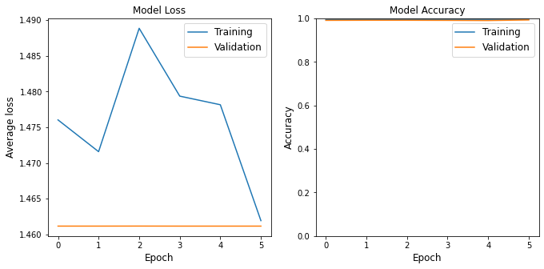

```python
plot(train_loss_history, val_loss_history, train_acc_history, val_acc_history)
```

```python
# Test the model
ytest = []
rtest = np.ones((0,10))
model.eval()  # eval mode (batchnorm uses moving mean/variance instead of mini-batch mean/variance)
with torch.no_grad():
    correct = 0
    total = 0
    for images, labels in test_loader:
        ytest = np.append(ytest, labels)
        images = images.to(device)
        labels = labels.to(device)
        outputs = model(images)
        _, predicted = torch.max(outputs.data, 1)
        total += labels.size(0)
        correct += (predicted == labels).sum().item()
        rtest = np.append(rtest, outputs.cpu(), axis=0)
print('Test Accuracy of the model on the 10000 test images: {} %'.format(100 * correct / total))
```

```
Test Accuracy of the model on the 10000 test images: 99.29 %
```

### One concern is that this model seem to start to overfit. This can be seen by how the traning loss starts increases a bit at epoch=1. This may be caused by a learning rate that is too high or the need to increase the dropout value. After experimenting with it, it is true that performing that will help decrease the training loss, however it will decrease the test accuracy too. Since this model still gives the best test accuracy, we have decided to go with this model.

```
Confusion matrix, without normalization
```

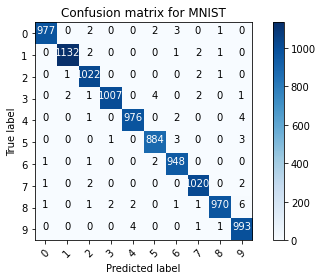

```python
cfm = confusion_matrix(np.argmax (rtest,axis=1), ytest)
plot_confusion_matrix(cfm, classes=range(10),
                      title='Confusion matrix for MNIST')
```

### Comparing this confusion matrix with the demo model's confusion matrix, both of them are very similar. This is because both of the have a very high test accuracy.

```python
# Save the model checkpoint
torch.save(model.state_dict(), 'model.ckpt')
```

# Section 3

### In this final section, we will be creating a CNN model in pytorch that will use the idata dataset that we have from lab 7. We will also evaluate the performance of the model and compare the results with the original model.

### In the first step, we first added a SimpleDataset function that will be used to get the idata set. Then, the train and test dataset is extracted. A change that we have here is that the test set will be from the idata dataset, which is located in the idata directory and refers to the labels.csv file that shows the name of the file and true label of it. These test images are converted to Tensors.

```python
import pandas as pd
import numpy as np
from torch.utils.data.dataset import Dataset

class SimpleDataset(Dataset):
    def __init__(self, data_path, csv_name, transform = None ):
        """
        Args:
            data_path (string): path to the folder where images and csv files are located
            csv_name (string): name of the csv lablel file
            transform: pytorch transforms for transforms and tensor conversion
        """
        # Set path
        self.data_path = data_path
        # Transforms
        self.transform = transform
        # Read the csv file
        self.data_info = pd.read_csv(data_path + csv_name, header=None)
        # First column contains the image paths
        self.image_arr = np.asarray(self.data_info.iloc[:, 0])
        # Second column is the labels
        self.label_arr = np.asarray(self.data_info.iloc[:, 1])
        # Calculate len
        self.data_len = len(self.data_info.index)


    def __getitem__(self, index):
        # Get image name from the pandas df
        single_image_name = self.image_arr[index]
        # Open image
        img_as_img = Image.open(self.data_path + single_image_name)
        if self.transform is not None:
              img_as_img = self.transform(img_as_img)

        # Get label(class) of the image based on the cropped pandas column
        single_image_label = self.label_arr[index]
        #convert to tensor to be consistent with MNIST dataset
        single_image_label = torch.LongTensor( [ single_image_label ] )[0]
        return (img_as_img, single_image_label)

    def __len__(self):
        return self.data_len


# Device configuration
device = torch.device('cuda:0' if torch.cuda.is_available() else 'cpu')

# MNIST dataset
train_dataset = torchvision.datasets.MNIST(root='./data/',
                                           train=True,
                                           transform=transforms.ToTensor(),
                                           download=True)

test_dataset = SimpleDataset( "./idata/", "labels.csv", transform=transforms.ToTensor())
```

### Next, the plot_confusion_matrix is re-created. However, this time it will accept two classes parameters, because the confusion matrix will not be a perfect square dimension. This is because the test data label has extra labels 10-19 that describes letter shapes A-J, which does not exist in the MNIST training set.

```python
def plot_confusion_matrix(cm, classes1, classes2,
                          normalize=False,
                          title='Confusion matrix',
                          cmap=plt.cm.Blues):
    """
    This function prints and plots the confusion matrix.
    Normalization can be applied by setting `normalize=True`.
    """
    if normalize:
        cm = cm.astype('float') / cm.sum(axis=1)[:, np.newaxis]
        print("Normalized confusion matrix")
    else:
        print('Confusion matrix, without normalization')

    #print(cm)

    plt.imshow(cm, interpolation='nearest', cmap=cmap)
    plt.title(title)
    plt.colorbar()
    tick_marks1 = np.arange(len(classes1))
    tick_marks2 = np.arange(len(classes2))
    plt.xticks(tick_marks1, classes1, rotation=45)
    plt.yticks(tick_marks2, classes2)

    fmt = '.2f' if normalize else 'd'
    thresh = cm.max() / 2.
    for i, j in itertools.product(range(cm.shape[0]), range(cm.shape[1])):
        plt.text(j, i, format(cm[i, j], fmt),
                 horizontalalignment="center",
                 color="white" if cm[i, j] > thresh else "black")

    plt.ylabel('True label')
    plt.xlabel('Predicted label')
    plt.tight_layout()
```

### Then, the hyperparameters for the model is being set. Then, the training and testing data are loaded. These steps are similar to the original pytorch model.

```python
# Hyperparameters
num_epochs = 6
num_classes = 20
batch_size = 100
learning_rate = 0.0001
```

```python
# Data loader
train_loader = torch.utils.data.DataLoader(dataset=train_dataset,
                                           batch_size=batch_size,
                                           shuffle=True)

test_loader = torch.utils.data.DataLoader(dataset=test_dataset,
                                          batch_size=batch_size,
                                          shuffle=False)
```

## Model

### Below is the model that we have. We are using an identical model to allow a fair comparison of using the idata test set with the MNIST test set.

```python
# Convolutional neural network (two convolutional layers)
class ConvNet(nn.Module):
    def __init__(self, num_classes=20):
        super(ConvNet, self).__init__()
        self.layer1 = nn.Sequential(
            nn.Conv2d(1, 16, kernel_size=5, stride=1, padding=2),
            nn.BatchNorm2d(16),
            nn.ReLU(),
            nn.MaxPool2d(kernel_size=2, stride=2)
            )
        self.layer2 = nn.Sequential(
            nn.Conv2d(16, 32, kernel_size=5, stride=1, padding=2),
            nn.BatchNorm2d(32),
            nn.ReLU(),
            nn.MaxPool2d(kernel_size=2, stride=2))
        self.fc = nn.Linear(7*7*32, num_classes)

    def forward(self, x):
        out = self.layer1(x)
        out = self.layer2(out)
        out = out.reshape(out.size(0), -1)
        out = self.fc(out)
        return out

model = ConvNet(num_classes).to(device)
```

## Training

### In this step, our model is trained based on the MNIST training set that we have and the hyperparameters. Again, this step if identical to the provided model.

```python
# Loss and optimizer
criterion = nn.CrossEntropyLoss()
optimizer = torch.optim.Adam(model.parameters(), lr=learning_rate)

# Keep track of average losses, training accuracy and validation accuracy for each epoch
train_loss_history = np.zeros(num_epochs)
train_acc_history  = np.zeros(num_epochs)
val_loss_history   = np.zeros(num_epochs)
val_acc_history    = np.zeros(num_epochs)

start_time = datetime.now()

for epoch in range(num_epochs):

    # Place network in training mode
    model.train()

    # Initialize running epoch loss and number correctly classified
    running_loss   = 0.0
    num_correct    = 0.0
    total_images   = 0.0

    for batch_num, (inputs, labels) in enumerate(train_loader):
        # [inputs] and [labels] is one batch of images and their classes
        inputs = inputs.to(device)
        labels = labels.to(device)

        # Forward pass
        outputs = model(inputs)
        loss = criterion(outputs, labels)

        # Backward and optimize
        optimizer.zero_grad()
        loss.backward()
        optimizer.step()

        # Update statistics for this batch
        curr_loss = loss.item()
        _, preds = torch.max(outputs, 1)
        curr_images = labels.cpu().data.numpy().size
        curr_correct = torch.sum(preds == labels.data.reshape(-1))

        # Update running statistics for this epoch
        running_loss += curr_loss
        num_correct += curr_correct
        total_images += curr_images

        # Log Progress every 200 batches
        if (batch_num + 1) % 200 == 0:
          log_progress(running_loss, batch_num, batch_size, epoch, num_epochs, train_loader)

    # Update statistics for epoch
    train_loss_history[epoch] = curr_loss #running_loss / total_images
    train_acc_history[epoch]  = float(num_correct)  / float(total_images)
    print("Train Avg. Loss: [{}] Acc: {} on {} images".format(
        round(train_loss_history[epoch],4), round(train_acc_history[epoch],4), total_images) )

    # ============================ Validation ==============================
    print("Validating...")
    # Place network in testing mode (won't need to keep track of gradients)
    model.eval()

    running_loss   = 0.0
    num_correct    = 0.0
    total_images   = 0.0

    for batch_num, (inputs, labels) in enumerate(test_loader):
        inputs = inputs.to(device)
        labels = labels.to(device)

        # Propagate batch through network
        outputs  = model(inputs)
        loss     = criterion(outputs, labels.squeeze())
        _, preds = torch.max(outputs, 1)

        # Update statistics for this batch
        running_loss  += loss.item()
        num_correct   += torch.sum(preds == labels.data.reshape(-1))
        total_images  += labels.cpu().data.numpy().size

        # Log Progress every 200 batches
        if (batch_num + 1) % 200 == 0:
          log_progress(running_loss, batch_num, batch_size, epoch, num_epochs, test_loader)

    # Update statistics for validation data
    val_loss_history[epoch] = loss.item() #running_loss / total_images
    val_acc_history[epoch]  = float(num_correct)  / float(total_images)
    print("Val Avg. Loss: [{}] Acc: {} on {} images\n".format(
        round(val_loss_history[epoch],4), val_acc_history[epoch], total_images))

print("Time Elapsed: {} seconds".format((datetime.now() - start_time).total_seconds()))
```

```
EPOCH [1/6]. Running Loss: 206.78 Progress: 33.33 %
EPOCH [1/6]. Running Loss: 265.96 Progress: 66.67 %
EPOCH [1/6]. Running Loss: 302.06 Progress: 100.0 %
Train Avg. Loss: [0.123] Acc: 0.8839 on 60000.0 images
Validating...
Val Avg. Loss: [2.3671] Acc: 0.5166666666666667 on 60.0 images

EPOCH [2/6]. Running Loss: 28.03 Progress: 33.33 %
EPOCH [2/6]. Running Loss: 51.49 Progress: 66.67 %
EPOCH [2/6]. Running Loss: 71.47 Progress: 100.0 %
Train Avg. Loss: [0.0817] Acc: 0.9699 on 60000.0 images
Validating...
Val Avg. Loss: [2.378] Acc: 0.6333333333333333 on 60.0 images

EPOCH [3/6]. Running Loss: 18.36 Progress: 33.33 %
EPOCH [3/6]. Running Loss: 34.79 Progress: 66.67 %
EPOCH [3/6]. Running Loss: 48.9 Progress: 100.0 %
Train Avg. Loss: [0.0706] Acc: 0.9786 on 60000.0 images
Validating...
Val Avg. Loss: [2.4399] Acc: 0.6666666666666666 on 60.0 images

EPOCH [4/6]. Running Loss: 13.61 Progress: 33.33 %
EPOCH [4/6]. Running Loss: 26.58 Progress: 66.67 %
EPOCH [4/6]. Running Loss: 38.21 Progress: 100.0 %
Train Avg. Loss: [0.0692] Acc: 0.9827 on 60000.0 images
Validating...
Val Avg. Loss: [2.5188] Acc: 0.6666666666666666 on 60.0 images

EPOCH [5/6]. Running Loss: 11.59 Progress: 33.33 %
EPOCH [5/6]. Running Loss: 21.46 Progress: 66.67 %
EPOCH [5/6]. Running Loss: 32.03 Progress: 100.0 %
Train Avg. Loss: [0.1003] Acc: 0.9856 on 60000.0 images
Validating...
Val Avg. Loss: [2.5292] Acc: 0.6666666666666666 on 60.0 images

EPOCH [6/6]. Running Loss: 9.28 Progress: 33.33 %
EPOCH [6/6]. Running Loss: 18.57 Progress: 66.67 %
EPOCH [6/6]. Running Loss: 27.77 Progress: 100.0 %
Train Avg. Loss: [0.0494] Acc: 0.987 on 60000.0 images
Validating...
Val Avg. Loss: [2.62] Acc: 0.6666666666666666 on 60.0 images

Time Elapsed: 243.437647 seconds
```

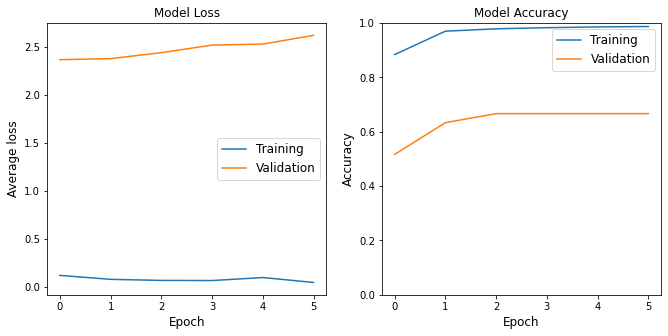

```python
plot(train_loss_history, val_loss_history, train_acc_history, val_acc_history)
```

```python
# Test the model
ytest = []
rtest = np.ones((0,20))
model.eval()  # eval mode (batchnorm uses moving mean/variance instead of mini-batch mean/variance)
with torch.no_grad():
    correct = 0
    total = 0
    for images, labels in test_loader:
        ytest = np.append(ytest, labels)
        images = images.to(device)
        labels = labels.to(device)
        outputs = model(images)
        _, predicted = torch.max(outputs.data, 1)
        total += labels.size(0)
        correct += (predicted == labels).sum().item()
        rtest = np.append(rtest, outputs, axis=0)
print('Test Accuracy of the model on the 10000 test images: {} %'.format(100 * correct / total))
```

```
Test Accuracy of the model on the 10000 test images: 66.66666666666667 %
```

### From the plots and results above, we can see that the training accuracy and loss is 0.987 and 0.0494 while the testing accuracy and loss is 0.666 and 2.62. Despite the high accuracy and low error of the training set, the testing prediction of the model is very poor. This shows that a high training accuracy does not correspond to a high testing accuracy. A 0.666 testing accuracy is very low, and in the confusion matrix below, we will be able to see on the major sources of errors. Looking at the plots above, it is interesting to see the major difference of the average loss and accuracy values between the training and testing set. This shows how the training and testing dataset may not be too similar, which is true as the testing set came from the idata that I have created. Looking at the model loss plot, we can see that the test loss keeps increasing as the epoch increases, which is not ideal. Additionally, we can see that the test accuracy stops increasing as the epoch reaches the value of 3. This shows that it has reached the maximum test accuracy at 66.6%.

### Comparing this result with the original experiment with MNIST test set, we can see major differences. The original experiment performed way better with a much higher test accuracy of 98.65% compared to 66.6% in this experiment. It also has a much lower loss. This is a huge finding because these two models are trained on the same training dataset, and the only difference is the test set. This shows that the test set used in this experiment is not similar to the training MNIST data. As a result, it will not be possible to have a high test accuracy.

### This is a similar finding to the result in lab7, where the test accuracy is very low when using logistic regression model. However, the test accuracy when using CNN is still better than logistic regression, based on my experimentation (66% vs 32%).

### Finally, the confusion matrix is plotted. Note that the A-J letters are shown as 10-19 labels.

```
Confusion matrix, without normalization
Label 10-19 represents A-J
```

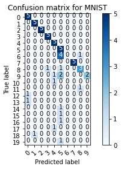

```python
cfm = confusion_matrix(np.argmax (rtest,axis=1), ytest)
plot_confusion_matrix(cfm[:10].T, classes1=range(10), classes2=range(20),
                      title='Confusion matrix for MNIST')
print("Label 10-19 represents A-J")
```

### From the confusion matrix, we can see that digits 0-5 and 7 is predicted perfectly. Digit 8 has a 3/5 correct prediction while digit 9 has a 2/5 correct prediction. We can also see that none of the digit 6 predictions are correct, and were mostly predicted as digit 5. Most of the errors came from the A-J letters, whose labels are not part of the training set, and thus their predictions will be wrong. Based on the confusion matrix, we can see that for my own handwritting most digits will be predicted well, however the model could not predict the digit 6. This may be a problem with my own handwriting, and also shows the limitation of prediction using MNIST training dataset on someone else's handwriting test set. When comparing this confusion matrix to the original model that has 98.65% test accuracy, there are some obvious differences. Firstly, this confusion matrix has 10 extra true labels. Secondly, the original model's confusion matrix clearly shows a diagonal blue boxes, which means that most predictions are correct. There are no other blue boxes outside the diagonal blue line of boxes. On the other hand, this does not happen in the confusion matrix above, because this model has a very poor prediction of the digit 6.

```python
# Save the model checkpoint
torch.save(model.state_dict(), 'model.ckpt')
```

### Next, we will see if there is an improvement in prediction for the idata2 dataset.

```python
# Device configuration
device = torch.device('cuda:0' if torch.cuda.is_available() else 'cpu')

# MNIST dataset
train_dataset = torchvision.datasets.MNIST(root='./data/',
                                           train=True,
                                           transform=transforms.ToTensor(),
                                           download=True)

test_dataset = SimpleDataset( "./idata2/", "labels.csv", transform=transforms.ToTensor())
```

### Then, the hyperparameters for the model is being set. Then, the training and testing data are loaded.

```python
# Hyperparameters
num_epochs = 6
num_classes = 20
batch_size = 100
learning_rate = 0.0001
```

```python
# Data loader
train_loader = torch.utils.data.DataLoader(dataset=train_dataset,
                                           batch_size=batch_size,
                                           shuffle=True)

test_loader = torch.utils.data.DataLoader(dataset=test_dataset,
                                          batch_size=batch_size,
                                          shuffle=False)
```

## Training

### In this step, our model is trained based on the MNIST training set that we have and the hyperparameters.

```python
# Loss and optimizer
criterion = nn.CrossEntropyLoss()
optimizer = torch.optim.Adam(model.parameters(), lr=learning_rate)

# Keep track of average losses, training accuracy and validation accuracy for each epoch
train_loss_history = np.zeros(num_epochs)
train_acc_history  = np.zeros(num_epochs)
val_loss_history   = np.zeros(num_epochs)
val_acc_history    = np.zeros(num_epochs)

start_time = datetime.now()

for epoch in range(num_epochs):

    # Place network in training mode
    model.train()

    # Initialize running epoch loss and number correctly classified
    running_loss   = 0.0
    num_correct    = 0.0
    total_images   = 0.0

    for batch_num, (inputs, labels) in enumerate(train_loader):
        # [inputs] and [labels] is one batch of images and their classes
        inputs = inputs.to(device)
        labels = labels.to(device)

        # Forward pass
        outputs = model(inputs)
        loss = criterion(outputs, labels)

        # Backward and optimize
        optimizer.zero_grad()
        loss.backward()
        optimizer.step()

        # Update statistics for this batch
        curr_loss = loss.item()
        _, preds = torch.max(outputs, 1)
        curr_images = labels.cpu().data.numpy().size
        curr_correct = torch.sum(preds == labels.data.reshape(-1))

        # Update running statistics for this epoch
        running_loss += curr_loss
        num_correct += curr_correct
        total_images += curr_images

        # Log Progress every 200 batches
        if (batch_num + 1) % 200 == 0:
          log_progress(running_loss, batch_num, batch_size, epoch, num_epochs, train_loader)

    # Update statistics for epoch
    train_loss_history[epoch] = curr_loss #running_loss / total_images
    train_acc_history[epoch]  = float(num_correct)  / float(total_images)
    print("Train Avg. Loss: [{}] Acc: {} on {} images".format(
        round(train_loss_history[epoch],4), round(train_acc_history[epoch],4), total_images) )

    # ============================ Validation ==============================
    print("Validating...")
    # Place network in testing mode (won't need to keep track of gradients)
    model.eval()

    running_loss   = 0.0
    num_correct    = 0.0
    total_images   = 0.0

    for batch_num, (inputs, labels) in enumerate(test_loader):
        inputs = inputs.to(device)
        labels = labels.to(device)

        # Propagate batch through network
        outputs  = model(inputs)
        loss     = criterion(outputs, labels.squeeze())
        _, preds = torch.max(outputs, 1)

        # Update statistics for this batch
        running_loss  += loss.item()
        num_correct   += torch.sum(preds == labels.data.reshape(-1))
        total_images  += labels.cpu().data.numpy().size

        # Log Progress every 200 batches
        if (batch_num + 1) % 200 == 0:
          log_progress(running_loss, batch_num, batch_size, epoch, num_epochs, test_loader)

    # Update statistics for validation data
    val_loss_history[epoch] = loss.item() #running_loss / total_images
    val_acc_history[epoch]  = float(num_correct)  / float(total_images)
    print("Val Avg. Loss: [{}] Acc: {} on {} images\n".format(
        round(val_loss_history[epoch],4), val_acc_history[epoch], total_images))

print("Time Elapsed: {} seconds".format((datetime.now() - start_time).total_seconds()))
```

```
EPOCH [1/6]. Running Loss: 193.38 Progress: 33.33 %
EPOCH [1/6]. Running Loss: 250.16 Progress: 66.67 %
EPOCH [1/6]. Running Loss: 287.57 Progress: 100.0 %
Train Avg. Loss: [0.1261] Acc: 0.8916 on 60000.0 images
Validating...
Val Avg. Loss: [2.44] Acc: 0.65 on 60.0 images

EPOCH [2/6]. Running Loss: 28.04 Progress: 33.33 %
EPOCH [2/6]. Running Loss: 51.95 Progress: 66.67 %
EPOCH [2/6]. Running Loss: 73.34 Progress: 100.0 %
Train Avg. Loss: [0.0421] Acc: 0.9688 on 60000.0 images
Validating...
Val Avg. Loss: [2.5701] Acc: 0.6666666666666666 on 60.0 images

EPOCH [3/6]. Running Loss: 18.32 Progress: 33.33 %
EPOCH [3/6]. Running Loss: 34.4 Progress: 66.67 %
EPOCH [3/6]. Running Loss: 50.1 Progress: 100.0 %
Train Avg. Loss: [0.0862] Acc: 0.9779 on 60000.0 images
Validating...
Val Avg. Loss: [2.604] Acc: 0.7 on 60.0 images

EPOCH [4/6]. Running Loss: 13.7 Progress: 33.33 %
EPOCH [4/6]. Running Loss: 26.68 Progress: 66.67 %
EPOCH [4/6]. Running Loss: 39.24 Progress: 100.0 %
Train Avg. Loss: [0.0679] Acc: 0.982 on 60000.0 images
Validating...
Val Avg. Loss: [2.6938] Acc: 0.6833333333333333 on 60.0 images

EPOCH [5/6]. Running Loss: 11.86 Progress: 33.33 %
EPOCH [5/6]. Running Loss: 23.15 Progress: 66.67 %
EPOCH [5/6]. Running Loss: 33.07 Progress: 100.0 %
Train Avg. Loss: [0.041] Acc: 0.9848 on 60000.0 images
Validating...
Val Avg. Loss: [2.6534] Acc: 0.75 on 60.0 images

EPOCH [6/6]. Running Loss: 9.25 Progress: 33.33 %
EPOCH [6/6]. Running Loss: 18.67 Progress: 66.67 %
EPOCH [6/6]. Running Loss: 28.48 Progress: 100.0 %
Train Avg. Loss: [0.0333] Acc: 0.9866 on 60000.0 images
Validating...
Val Avg. Loss: [2.7504] Acc: 0.75 on 60.0 images

Time Elapsed: 250.045572 seconds
```

## Plots

### In the first plot below, it shows what happens with the average loss and accuracy of both the training and testing through the epochs.

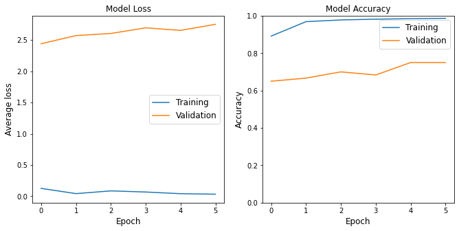

```python
plot(train_loss_history, val_loss_history, train_acc_history, val_acc_history)
```

```python
# Test the model
ytest = []
rtest = np.ones((0,20))
model.eval()  # eval mode (batchnorm uses moving mean/variance instead of mini-batch mean/variance)
with torch.no_grad():
    correct = 0
    total = 0
    for images, labels in test_loader:
        ytest = np.append(ytest, labels)
        images = images.to(device)
        labels = labels.to(device)
        outputs = model(images)
        _, predicted = torch.max(outputs.data, 1)
        total += labels.size(0)
        correct += (predicted == labels).sum().item()
        rtest = np.append(rtest, outputs, axis=0)
print('Test Accuracy of the model on the 10000 test images: {} %'.format(100 * correct / total))
```

```
Test Accuracy of the model on the 10000 test images: 75.0 %
```

### Finally, the confusion matrix is plotted.

```
Confusion matrix, without normalization
Label 10-19 represents A-J
```

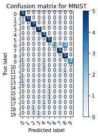

```python
cfm = confusion_matrix(np.argmax (rtest,axis=1), ytest)
plot_confusion_matrix(cfm[:10].T, classes1=range(10), classes2=range(20),
                      title='Confusion matrix for MNIST')
print("Label 10-19 represents A-J")
```

### With the idata2 test set, which is the handwritten digits that has been dilated (thicker lines), we are able to get an improved result compared to using idata. The prediction improves from 66.6% in idata to 75% using idata2 test set. Note that when using the logistic regression model in Lab 7, the validation/test accuracy was at 50%. Once again, this shows that using this CNN model will give a better result to using logistic regression. From the loss vs epoch plot, we can see that the loss is starting to increase as more epochs. This shows that model may hae started to overfit. From epoch 4 to 5 in the accuracy plot, we can see that there is barely any improvement in validation accuracy. From the confusion matrix, we can see that we actually only have 5 misclassified entries, which are three '6' digits and two '9' digits. Other than that, the misclassifications came from the alphabets, which will definetely be misclassified as the labels are not part of the training data.

# Conclusion

### In this lab, we have learned about creating Convolution Neural Networks using both Pytorch and Keras for MNSIT dataset. We first analyzed the demo model in pytorch and keras and compare how performance may change if we are to use GPU or not (in Google Collab). Then, we attempted to create the demo model of Keras in Pytorch and vice versa to see if there are any performance differences, which actually do differ. Then, we attempted to create our own model in PyTorch, which involves experimentation with different layers and parameters that would allow best test accuracy without overfitting. Finally, we tested the original demo pytorch model but using our idata test set from Lab 7, in which we found that the CNN model would give a better test accuracy compared to Logistic Regression done in Lab 7.